# The impact of storms in the US

John Lee

24 September 2015

This report summarises the effect of extreme weather events in the U.S. on society. The U.S. National Oceanic and Atmospheric Administration’s (NOAA) storm database was used to assess this. The effect of population health was assessed by analysing the number of injuries and deaths caused by extreme weather events. The economic impact of these events was assessed by the estimated cost of the damage to both crops and property. In both estimates, tornados prove to be most devastating.

# Data Processing

The following librariess are used during the analaysis:

```r
library(data.table)
library(ggplot2)
```

The data used in this report is published by the U.S. National Oceanic and Atmospheric Administration’s (NOAA) storm database. The database tracks characteristics of major storms and weather events in the United States, including when and where they occur, as well as estimates of any fatalities, injuries, and property damage.

The data was downloaded from the following URL:

```r
file_url <- "https://d396qusza40orc.cloudfront.net/repdata%2Fdata%2FStormData.csv.bz2"
if(!file.exists("storm.csv.bz2")){
    download.file(file_url, destfile = "storm.csv.bz2",method = "curl")
}
```

The data was read using the read.csv() package function in base R and converted to the data.table datatype:

```r
connection<- bzfile("storm.csv.bz2")
storm_data <- read.csv(connection)
storm_data <- data.table(storm_data)
```

The data set has more than 900,000 entries with 37 variables for each entry:

```r
dim(storm_data)
```

```
## [1] 902297     37
```

The data was subsetted for the variables required for the following analysis:

```r
s_data <- storm_data[,.(BGN_DATE, EVTYPE, FATALITIES, INJURIES, CROPDMG,CROPDMGEXP,PROPDMG,PROPDMGEXP)]
remove(storm_data)
```

Pertinent to the second part of the analysis performed, the following variables have no missing values:

```r
s_data[,which(is.na(CROPDMG))]
```

```
## integer(0)
```

```r
s_data[,which(is.na(CROPDMGEXP))]
```

```
## integer(0)
```

```r
s_data[,which(is.na(PROPDMG))]
```

```
## integer(0)
```

```r
s_data[,which(is.na(PROPDMGEXP))]
```

```
## integer(0)
```

# Results

## Events most harmful with respect to population health

Between the years 1950 and 2011 the total number of deaths for each of the 985 event categories was calculated. Events that cumulatively caused more than 50 fatalities are listed below. We see that tornadoes cause both death and injury many fold higher than other events. Different categories describing excessive heat indicate this is the second most common weather in which people are injured or die. Different types of storms appear to cumulatively be the next weather event to take human lives but the different categories describing such events were not merged to provide a more thorough understanding of the impact of such events.

```r
health_impact  <- s_data[,.(
    Number_of_events = .N,
    Total_injuries = sum(INJURIES),
    Total_fatalities = sum(FATALITIES)),
    by = EVTYPE][order(-Total_injuries)]
health_impact[Total_fatalities>50]
```

```
##                      EVTYPE Number_of_events Total_injuries
##  1:                 TORNADO            60652          91346
##  2:               TSTM WIND           219940           6957
##  3:                   FLOOD            25326           6789
##  4:          EXCESSIVE HEAT             1678           6525
##  5:               LIGHTNING            15754           5230
##  6:                    HEAT              767           2100
##  7:               ICE STORM             2006           1975
##  8:             FLASH FLOOD            54277           1777
##  9:       THUNDERSTORM WIND            82563           1488
## 10:            WINTER STORM            11433           1321
## 11:       HURRICANE/TYPHOON               88           1275
## 12:               HIGH WIND            20212           1137
## 13:              HEAVY SNOW            15708           1021
## 14:                WILDFIRE             2761            911
```

[output cut: 49 more lines]

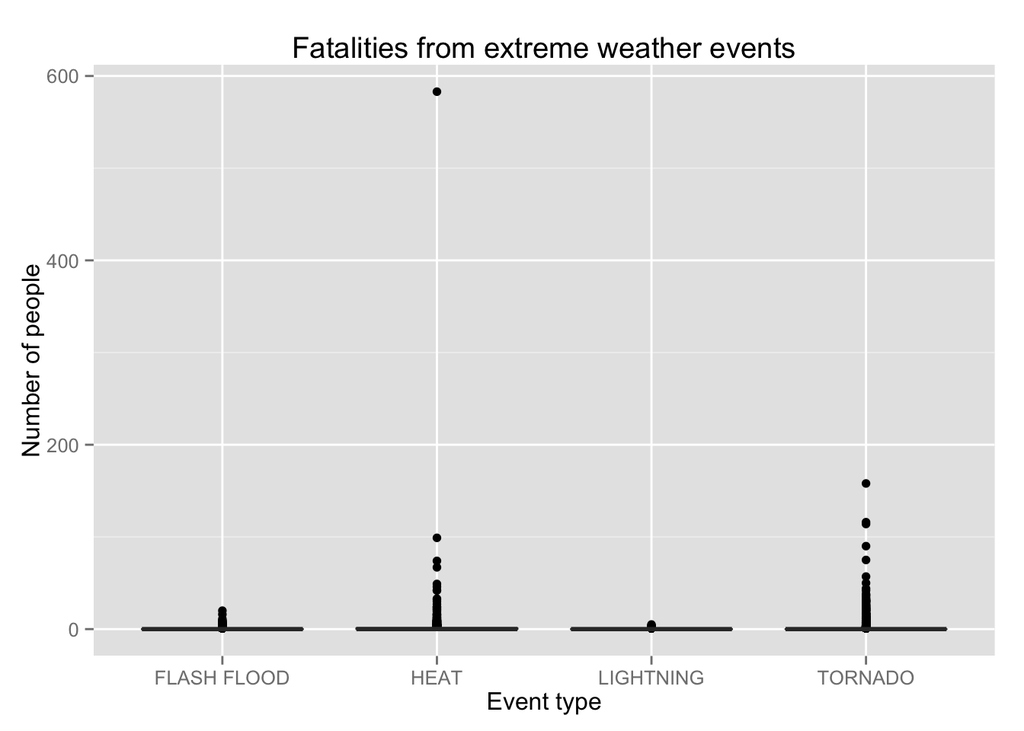

```r
s_data[EVTYPE == "EXCESSIVE HEAT", EVTYPE := "HEAT"]
plot_data <- s_data[
    EVTYPE %in% c("TORNADO","HEAT","FLASH FLOOD","LIGHTNING")]
plot_data[,EVTYPE := droplevels(EVTYPE)]

p <- ggplot(plot_data, aes(EVTYPE, FATALITIES))
p + geom_boxplot() +
    ggtitle("Fatalities from extreme weather events") +
    xlab("Event type")+
    ylab("Number of people")
```

## Events in the NOAA database with the greatest economic consequences

In assessing the economic consequences of the extreme weather events in this database we must have a closer look at the PROPDMG, PROPDMGEXP, CROPDMG, and CROPDMGEXP variables. A nice summary of these variables can be observed at the URL: https://github.com/flyingdisc/RepData_PeerAssessment2/blob/master/how-to-handle-PROPDMGEXP.md

To summarise the account given in the report at this URL, the damage to crops can be calculated by assessed by multiplying CROPDMG by CROPDMGEXP. Property damage can be obtained in a similar manner.

The values that the these variables can take are:

```r
s_data[,unique(CROPDMGEXP)]
```

```
## [1]   M K m B ? 0 k 2
## Levels:  ? 0 2 B k K m M
```

```r
s_data[,unique(PROPDMGEXP)]
```

```
##  [1] K M   B m + 0 5 6 ? 4 2 3 h 7 H - 1 8
## Levels:  - ? + 0 1 2 3 4 5 6 7 8 B h H K m M
```

```r
multiplier <- c("?" = 0, "+" = 0, "-"= 0,  "0"= 1, "1"= 10, "2"= 100, "3"= 1000, "4"= 10000, "5"= 100000, "6"= 1000000, "7"= 10000000, "8"= 100000000, "B"= 1000000, "h"= 100, "H"= 100, "K"= 1000, "m"= 1000000, "M"=1000000 )
economic_impact <- s_data[,
        .(Crop_damage = sum(na.omit(CROPDMG * multiplier[CROPDMGEXP])/(1*10^9)),
        Property_damage = sum(na.omit(PROPDMG * multiplier[PROPDMGEXP]))/(1*10^9)),
        by = EVTYPE]
economic_impact <- economic_impact[,
            Total_damage := Property_damage+Crop_damage][order(-Total_damage)]
economic_impact[Total_damage>50]
```

```
##                 EVTYPE Crop_damage Property_damage Total_damage
##  1:            TORNADO  0.13108411      3163.59418   3163.72527
##  2:        FLASH FLOOD  0.30229310      1412.65013   1412.95243
##  3:          TSTM WIND  0.15328235      1332.75844   1332.91172
##  4:              FLOOD  0.71248145       878.52981    879.24229
##  5:  THUNDERSTORM WIND  0.10128305       874.09115    874.19244
##  6:               HAIL  0.82163215       675.14163    675.96326
##  7:          LIGHTNING  0.00442409       602.87648    602.88091
##  8: THUNDERSTORM WINDS  0.03564410       440.91173    440.94737
##  9:          HIGH WIND  0.07885230       321.04626    321.12511
## 10:       WINTER STORM  0.00445300       131.15725    131.16170
## 11:         HEAVY SNOW  0.01529510       121.44084    121.45614
## 12:           WILDFIRE  0.03321280        80.81400     80.84721
## 13:        STRONG WIND  0.00789350        62.88145     62.88934
## 14:          ICE STORM  0.00370855        62.06781     62.07152
## 15:         HIGH WINDS  0.00562060        54.97365     54.97927
## 16:         HEAVY RAIN  0.08269980        50.19809     50.28079
```

Just as with the population data a large number of events related to winds have a high impact. Excluding tornados, events related to wind are summarised below. They are selected in a crude manner by simply selecting for events containing the word “wind” in their title. This includes a broad spectrum of events including “HIGH WINDS DUST STORM”, “EXTREME WIND CHILLS”" and “THUNDERSTORM WINDS LIGHTNING”" The number of event types and the total damage caused by them (in billions of U.S. dollars) is reported below:

```r
economic_impact[grep("WIND",EVTYPE),{print(.N) ; sum(Total_damage)} ]
```

```
## [1] 216
```

```
## [1] 3117.755
```